# NEPA Decarbonization Technology Analysis: Deliverable 4

Multi-State and Multi-Department Projects

Published

August 21, 2026

## Executive Summary

**NoteKey Findings**

- **Multi-state projects** represent a subset of decarbonization technology projects that span state boundaries, often involving transmission lines or large-scale renewable energy connections
- **Strict multi-department projects** (based on multiple lead agencies in metadata) are relatively rare
- **Expanded multi-agency projects** (strict metadata OR high-confidence coagency text signal) produce a materially larger N
- Geographic patterns reveal regional clusters of interstate cooperation

This report aims to create the following set of deliverables:

> Data on geography/project location; whether projects are multi-state or multi-agency

It analyzes decarbonization technology projects that cross administrative boundaries—either spanning multiple states or involving multiple federal agencies. These projects often represent larger, more complex undertakings that require coordination across jurisdictions. Table 1 reports total multi-state and multi-department project counts used in this report.

Table 1: Summary of cross-boundary projects

| Category | Count |
| --- | --- |
| Multi-state projects | 841 |
| Multi-department projects | 301 |

Note that some tables and figures below are filtered for clarity: the state connections table shows only state pairs with 5+ shared projects, the interstate map shows only state pairs with 10+ shared projects, and the top connections table shows the 10 highest-volume corridors.

The multi-department count reflects projects identified with the current expanded multi-department definition.

# Multi-State Projects

Multi-state projects are those where the project footprint extends across state boundaries. These typically include:

- Interstate transmission lines
- Pipeline connections
- Large renewable energy projects near state borders

## Process Type Breakdown

Figure 1 shows the distribution of NEPA process types among all multi-state decarbonization technology projects.[^1]

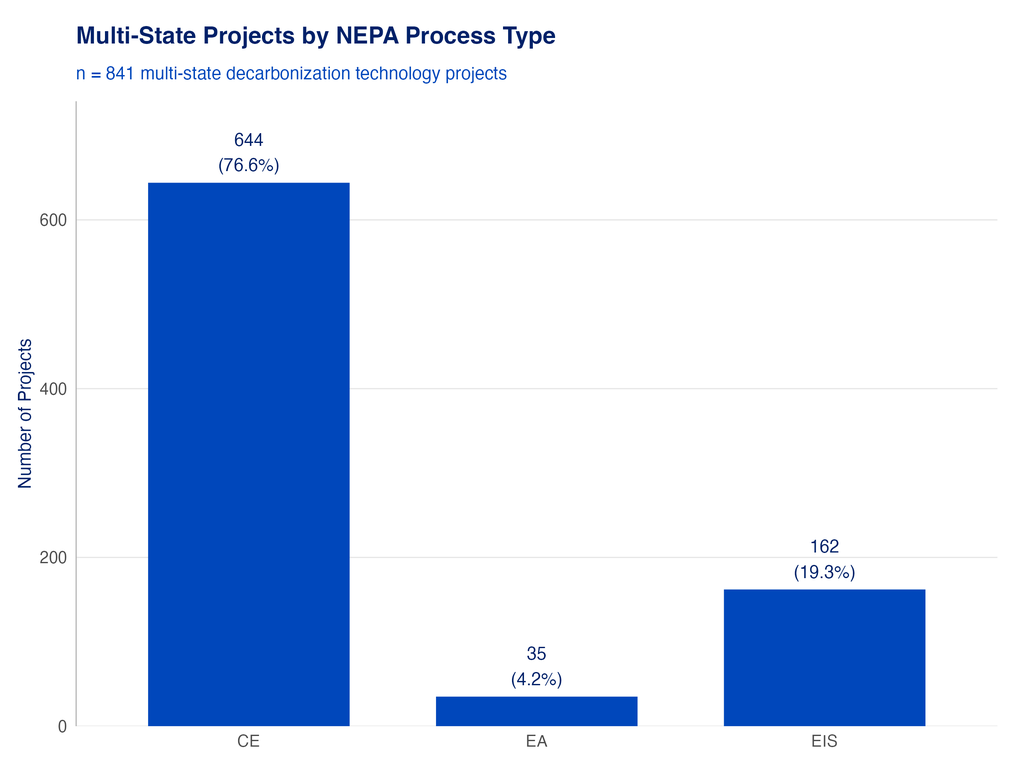

Figure 1: Distribution of NEPA process types for multi-state decarbonization technology projects

## State Connections Table

Table 2 shows state connection pairs with 5 or more shared projects, broken down by NEPA review process type. This threshold filters out infrequent connections to focus on the most active interstate corridors.

Table 2: Multi-state project connections by NEPA process type (connections with 5+ projects)

| State connections | Categorical Exclusion | Environmental Impact Statement | Environmental Assessment | Total |
| --- | --- | --- | --- | --- |
| Oregon, Washington | 78 | 8 | 1 | 87 |
| Kansas, Missouri | 47 | 3 | 0 | 50 |
| Colorado, New Mexico | 40 | 3 | 0 | 43 |
| Virginia, West Virginia | 27 | 1 | 0 | 28 |
| Nebraska, Nevada | 21 | 0 | 0 | 21 |
| California, Nevada | 6 | 11 | 3 | 20 |
| Arizona, California | 9 | 5 | 4 | 18 |
| Arizona, California, Nevada | 13 | 2 | 2 | 17 |
| Colorado, Washington | 17 | 0 | 0 | 17 |
| Nebraska, Wyoming | 11 | 0 | 2 | 13 |
| Idaho, Montana, Oregon, Washington | 4 | 8 | 0 | 12 |
| Idaho, Washington | 9 | 1 | 2 | 12 |
| Arizona, Colorado, Montana, Nebraska, New Mexico, Utah, Wyoming | 10 | 0 | 0 | 10 |
| California, Idaho, Montana, Nevada, Oregon, Utah, Washington, Wyoming | 8 | 2 | 0 | 10 |
| Arizona, New Mexico | 3 | 6 | 0 | 9 |
| Colorado, Nebraska | 9 | 0 | 0 | 9 |
| Colorado, Wyoming | 8 | 1 | 0 | 9 |
| Arkansas, Washington | 8 | 0 | 0 | 8 |
| Arizona, California, Colorado, Idaho, Montana, Nevada, New Mexico, Oregon, Utah, Washington, Wyoming | 0 | 7 | 0 | 7 |
| California, Oregon | 3 | 3 | 1 | 7 |
| Idaho, Montana | 5 | 2 | 0 | 7 |
| Utah, Washington | 7 | 0 | 0 | 7 |
| California, Connecticut, Delaware, Illinois, Kansas, Massachusetts, Minnesota, New York, North Carolina, South Carolina, Utah, Washington, West Virginia | 6 | 0 | 0 | 6 |
| California, Nebraska | 6 | 0 | 0 | 6 |
| Colorado, Utah | 6 | 0 | 0 | 6 |
| Idaho, Nebraska | 6 | 0 | 0 | 6 |
| Idaho, Oregon, Washington | 2 | 3 | 1 | 6 |
| Rhode Island, Washington | 5 | 1 | 0 | 6 |
| Arkansas, Missouri, Oklahoma | 3 | 0 | 2 | 5 |
| Maine, Washington | 3 | 1 | 1 | 5 |
| Vermont, Washington | 3 | 0 | 2 | 5 |
| Total | 534 | 161 | 35 | 730 |

Filtered to show only state-pair connections with 5 or more shared projects.

## Interstate Connections Map

Figure 2 visualizes the connections between states that share decarbonization technology projects. Line thickness reflects the number of shared projects, with labels highlighting the most active connections.

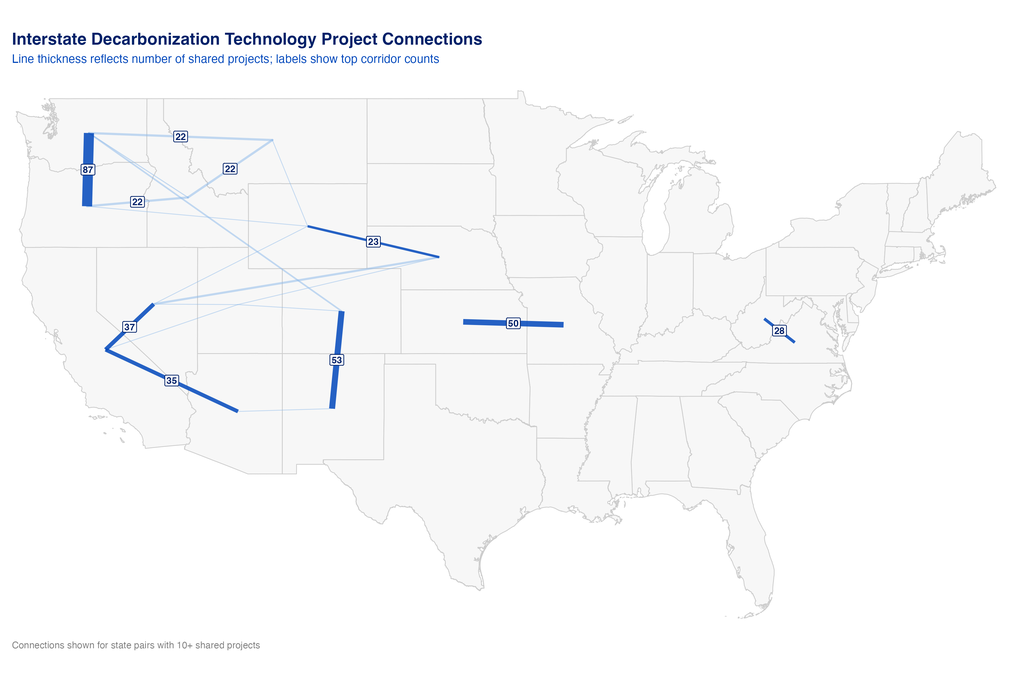

Figure 2: Interstate decarbonization technology project connections. Line thickness reflects number of shared projects; labels show counts for top connections.

## Top Connections Detail

Table 3 provides detail on the top 10 state connections by project volume, including the types of projects involved. Project types are deduplicated and sorted by frequency.

Table 3: Top 10 interstate connections with project types (sorted by frequency)

| State Connections | Distinct Project Types<sup>1</sup> | Categorical Exclusion | Environmental Assessment | Environmental Impact Statement | Total |
| --- | --- | --- | --- | --- | --- |
| Oregon - Washington | Electricity Transmission, Utilities, Waste Management, Land Development - Other, Surface Transportation - Other, Water Resources - Other, Broadband, Vegetation and Fuels Management, Public and Recreat… | 78 | 1 | 8 | 87 |
| Kansas - Missouri | Utilities, Research and Development, Surface Transportation - Other, Waste Management, Land Development - Urban, Manufacturing, Renewable Energy Production - Energy Storage, Electricity Transmission, … | 47 | 0 | 3 | 50 |
| Colorado - New Mexico | Utilities, Electricity Transmission, Land Development - Other, Broadband, Land Use or Forest Management Plan, Surface Transportation - Other, Waste Management, and Guidance, Laws, Policies, Regulation… | 40 | 0 | 3 | 43 |
| Virginia - West Virginia | Research and Development, Waste Management, Utilities, Conventional Energy Production - Other, Land Development - Other, and Guidance, Laws, Policies, Regulations, Renewable Energy Production - Solar,… | 27 | 0 | 1 | 28 |
| Nebraska - Nevada | Utilities, Electricity Transmission, Land Development - Other, Broadband, Ecosystem Management and Restoration, Water Resources - Irrigation and Water Supply, Conventional Energy Production - Other, R… | 21 | 0 | 0 | 21 |
| California - Nevada | Electricity Transmission, Utilities, Vegetation and Fuels Management, Ecosystem Management and Restoration, Land Development - Other, Land Use or Forest Management Plan, Public and Recreational Land U… | 6 | 3 | 11 | 20 |
| Arizona - California | Electricity Transmission, Utilities, Vegetation and Fuels Management, Surface Transportation - Other, Waste Management, Land Development - Other, Land Use or Forest Management Plan, Routine Maintenanc… | 9 | 4 | 5 | 18 |
| Arizona - California - Nevada | Electricity Transmission, Utilities, Waste Management, and Guidance, Laws, Policies, Regulations, Vegetation and Fuels Management, Ecosystem Management and Restoration, Renewable Energy Production - H… | 13 | 2 | 2 | 17 |
| Colorado - Washington | Electricity Transmission, Utilities, Vegetation and Fuels Management, Broadband, Ecosystem Management and Restoration, Emergency and Disaster Response, Land Use or Forest Management Plan, Rangeland Ma… | 17 | 0 | 0 | 17 |
| Nebraska - Wyoming | Electricity Transmission, Utilities, Vegetation and Fuels Management, Waste Management, Broadband, Onshore, Renewable Energy Production - Wind, Surface Transportation - Other, Water Resources - Other | 11 | 2 | 0 | 13 |

<sup>1</sup> Project types are ordered by frequency of appearance within each state connection.

## Word Clouds by NEPA Process Type

The next three figures break multi-state project types out by NEPA process type.

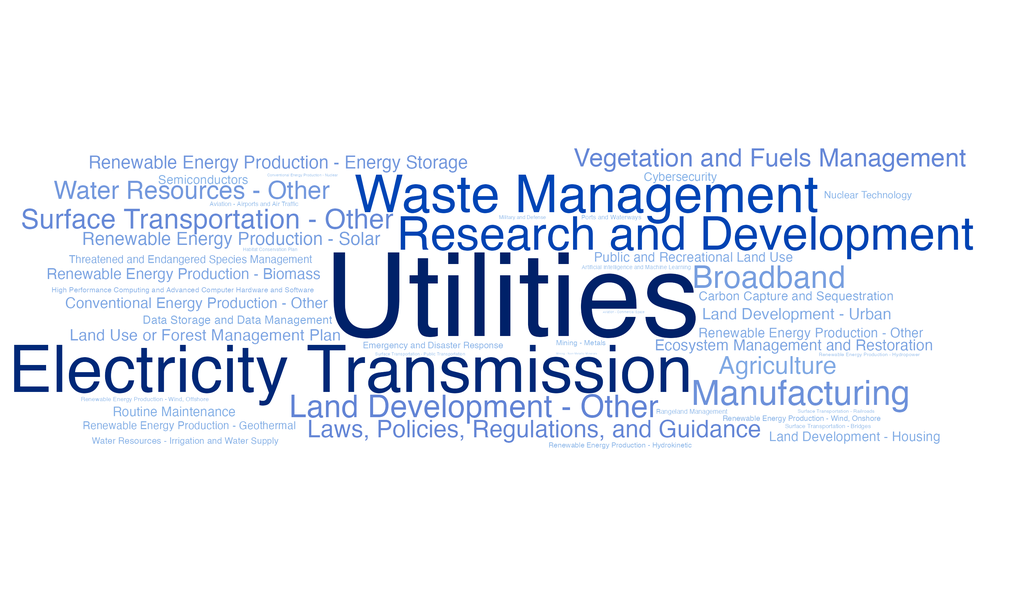

Figure 3: Multi-state project types word cloud for Categorical Exclusions (CE).

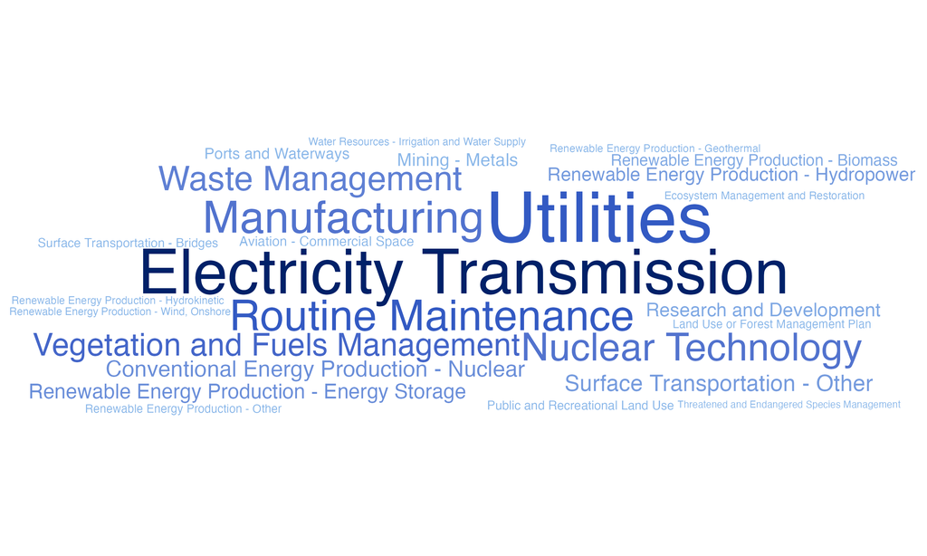

Figure 4: Multi-state project types word cloud for Environmental Assessments (EA).

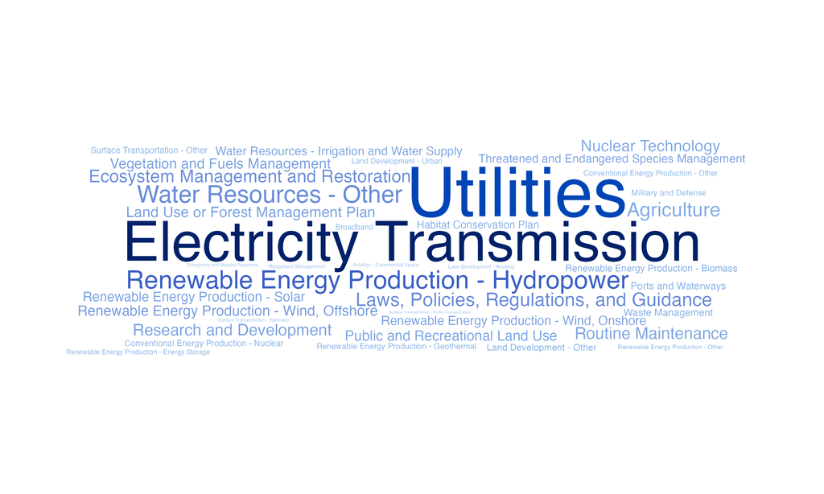

Figure 5: Multi-state project types word cloud for Environmental Impact Statements (EIS).

## Sample of Complex Multi-State Projects

Table 4 shows a small sample of projects that span many states and/or very wide state footprints.

Table 4: Sample of geographically complex multi-state projects

| Project Title | State Footprint | Number of States | Project Types |
| --- | --- | --- | --- |
| MacroAlgae Research Inspiring Novel Energy Resources (MARINER) Program (FOA No. DE-FOA-0001726) | Alabama, Alaska, California, Colorado, Connecticut, Delaware, District Of Columbia, Florida, Georgia, Hawaii, Illinois, Louisiana, Maine, Maryland, Massachusetts, Mississippi, New Hampshire, New Mexic… | 25 | Renewable Energy Production - Biomass, Research and Development, Agriculture, Waste Management, Water Resources - Other |
| Harnessing Emissions into Structures Taking Inputs from the Atmosphere (HESTIA) Program | Alaska, Arizona, California, Colorado, Florida, Georgia, Illinois, Indiana, Maine, Massachusetts, Michigan, New York, North Carolina, Oregon, Pennsylvania, South Carolina, Tennessee, Texas, Washington… | 20 | Research and Development, Carbon Capture and Sequestration, Manufacturing, Waste Management, Land Development - Housing, Land Development - Urban |
| Submarine Hydrokinetic and Riverine Kilo-Megawatt Systems SHARKS | Alaska, California, Colorado, Georgia, Illinois, Maine, Maryland, Massachusetts, Michigan, New Hampshire, New Jersey, New Mexico, New York, Oregon, Pennsylvania, Tennessee, Texas, Virginia, Washington… | 20 | Renewable Energy Production - Hydrokinetic, Research and Development, Waste Management, Water Resources - Other |
| Nationwide Public Safety Broadband Network for the Non-Contiguous United States | Alaska, Hawaii | 2 | Broadband, Utilities, Emergency and Disaster Response |
| Campbell Creek Science Center, Exterior Power Restoration (Light Pole) Project | Alaska, Nebraska | 2 | Electricity Transmission, Utilities |
| Aerodynamic Turbines, Lighter and Afloat, with Nautical Technologies and Integrated Servo-control (ATLANTIS) Program | Alabama, California, Colorado, Illinois, Maine, Maryland, Massachusetts, Michigan, New Jersey, New Mexico, New York, Rhode Island, Texas, Utah, Virginia, Washington | 16 | Renewable Energy Production - Wind, Offshore, Research and Development, Waste Management, Artificial Intelligence and Machine Learning, High Performance Computing and Advanced Computer Hardware and So… |
| Harnessing Emissions into Structures Taking Inputs from the Atmosphere (HESTIA) Program (FOA Numbers DE-FOA-0002625 and DE-FOA-0002626) | Colorado, Georgia, Illinois, Indiana, Maine, Massachusetts, Michigan, New York, North Carolina, Pennsylvania, South Carolina, Tennessee, Texas, Washington, Wisconsin | 15 | Research and Development, Carbon Capture and Sequestration, Manufacturing, Waste Management, Land Development - Housing |
| Cobscook Bay Tidal Energy Project | Maine, Washington | 2 | Renewable Energy Production - Hydrokinetic, Renewable Energy Production - Hydropower |
| Bangor Hydro-Electric Company Northeast Reliability Interconnect | Maine, Washington | 2 | Electricity Transmission |
| Underwater Active Acoustic Monitoring Support for Marine Hydrokinetic Energy Projects | Maine, Washington | 2 | Renewable Energy Production - Hydrokinetic, Research and Development, Manufacturing, Ecosystem Management and Restoration, Water Resources - Other |

# Multi-Department Projects

This section reports two definitions:

- **Strict metadata**: `project_multi_department` (multiple lead agencies in metadata).
- **Expanded multi-department**: `project_multi_agency` (strict metadata OR high-confidence coagency text signal from document pages).

## Process Type Breakdown

Figure 6 shows the distribution of NEPA process types for the expanded multi-department definition.

Multi-department projects are overwhelmingly EIS-level reviews (89%), with CEs and EAs together accounting for just 11% of the portfolio. This is a much sharper EIS skew than in the multi-state population, and it makes conceptual sense: EIS reviews are the longest and most resource-intensive NEPA pathway, and the need to formally coordinate across multiple federal agencies is most common in exactly these high-complexity situations. Projects requiring EIS-level review are the ones most likely to trigger interagency involvement through cooperating agency relationships or overlapping jurisdictions.

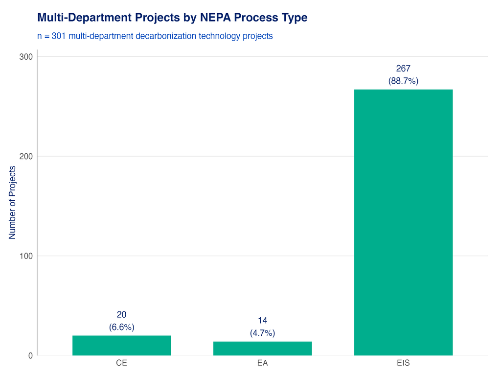

Figure 6: Distribution of NEPA process types for expanded multi-department decarbonization technology projects.

## Department Connections Table

Table 5 lists agency combinations that share projects, along with the types of projects involved. Project types are deduplicated and sorted by frequency.

The Department of Energy appears in nearly every multi-department pairing, reflecting its central role in both permitting energy infrastructure and managing research facilities. The most project-rich combinations are DOE with DOD (3 shared projects spanning transmission, R&D, and military-adjacent energy uses) and DOE paired with DOI, USDA, Commerce, and GSA (2 projects each). Project types signal two distinct collaboration logics: an energy-infrastructure track (electricity transmission, utilities, renewable energy production) and a research-and-management track (R&D, ecosystem management, waste management). The DOI–Homeland Security pairing stands out as non-DOE coordination, anchored by solar and emergency-preparedness projects.

Table 5: Strict metadata multi-department projects by agency combination

| Department connections | Distinct Project Types<sup>1</sup> | Total |
| --- | --- | --- |
| Department of Energy, Department of Defense | Electricity Transmission, Research and Development, Water Resources - Other, Cybersecurity, Emergency and Disaster Response, Land Development - Other, Laws, Policies, Regulations, and Guidance, Manufa… | 3 |
| Department of Energy, Department of Agriculture | Renewable Energy Production - Biomass, Waste Management, Ecosystem Management and Restoration, Electricity Transmission, Land Development - Other, Manufacturing, Research and Development, Water Resour… | 2 |
| Department of Energy, Department of Commerce | Research and Development, Renewable Energy Production - Solar, Renewable Energy Production - Wind, Offshore, Renewable Energy Production - Wind, Onshore, Waste Management, Water Resources - Other | 2 |
| Department of Energy, General Services Administration | Utilities, Data Storage and Data Management, High Performance Computing and Advanced Computer Hardware and Software, Renewable Energy Production - Solar, Waste Management | 2 |
| Department of the Interior, Department of Energy | Utilities, Broadband, Electricity Transmission, Land Use or Forest Management Plan, Laws, Policies, Regulations, and Guidance, Surface Transportation - Other | 2 |
| Department of the Interior, Department of Homeland Security | Renewable Energy Production - Solar, Waste Management, Emergency and Disaster Response, Land Development - Other, Military and Defense, Public and Recreational Land Use, Renewable Energy Production - … | 2 |
| Department of Energy, Department of Housing and Urban Development | Ecosystem Management and Restoration, Land Development - Urban, Renewable Energy Production - Geothermal, Waste Management, Water Resources - Other | 1 |
| Department of Energy, Department of State, International Assistance Programs | Renewable Energy Production - Solar, Renewable Energy Production - Wind, Onshore, Research and Development, Waste Management | 1 |
| Department of Energy, Department of the Interior | Broadband, Electricity Transmission, Laws, Policies, Regulations, and Guidance, Utilities | 1 |
| Department of Energy, Department of the Interior | Land Development - Other, Utilities, Water Resources - Other | 1 |
| Department of Homeland Security, Department of Energy | Cybersecurity, Military and Defense, Research and Development, Utilities, Waste Management | 1 |
| Department of Transportation, Department of the Interior | Electricity Transmission, Surface Transportation - Other | 1 |
| Department of the Interior, Department of Agriculture | Electricity Transmission, Utilities | 1 |

<sup>1</sup> Project types are ordered by frequency of appearance within each agency combination.

## Department Collaboration Hubs

Table 6 ranks departments by their collaborative footprint. The bridge score combines breadth (number of unique partner departments) with volume (total shared project ties, log-scaled) to identify departments that are both broadly connected and frequently involved—not just departments with one large partnership.

Table 6: Department collaboration hubs in parsed clean-energy EIS co-agency projects

| Department | Unique partner departments | Collaborative project ties | Most frequent partner | Projects with top partner | Bridge score |
| --- | --- | --- | --- | --- | --- |
| Department of the Interior | 12 | 209 | Department of Defense | 56 | 64.17 |
| Department of Defense | 13 | 124 | Department of the Interior | 56 | 62.77 |
| Department of Energy | 11 | 96 | Department of the Interior | 38 | 50.32 |
| Environmental Protection Agency | 11 | 89 | Department of the Interior | 45 | 49.50 |
| Other Independent Agencies | 8 | 63 | Nuclear Regulatory Commission | 43 | 33.27 |
| Major Independent Agencies | 9 | 33 | Department of Defense | 8 | 31.74 |
| Department of Agriculture | 8 | 51 | Department of the Interior | 29 | 31.61 |
| Department of Homeland Security | 8 | 22 | Department of the Interior | 5 | 25.08 |
| Department of Transportation | 7 | 15 | Major Independent Agencies | 4 | 19.41 |
| Department of Commerce | 5 | 27 | Department of the Interior | 14 | 16.66 |
| Nuclear Regulatory Commission | 4 | 46 | Other Independent Agencies | 43 | 15.40 |
| Council on Environmental Quality | 5 | 9 | Department of the Interior | 4 | 11.51 |
| Federal Energy Regulatory Commission | 3 | 8 | Department of Defense | 4 | 6.59 |
| General Services Administration | 3 | 3 | Department of Defense | 1 | 4.16 |
| Advisory Council on Historic Preservation | 2 | 4 | Department of the Interior | 3 | 3.22 |
| Department of State | 1 | 1 | General Services Administration | 1 | 0.69 |

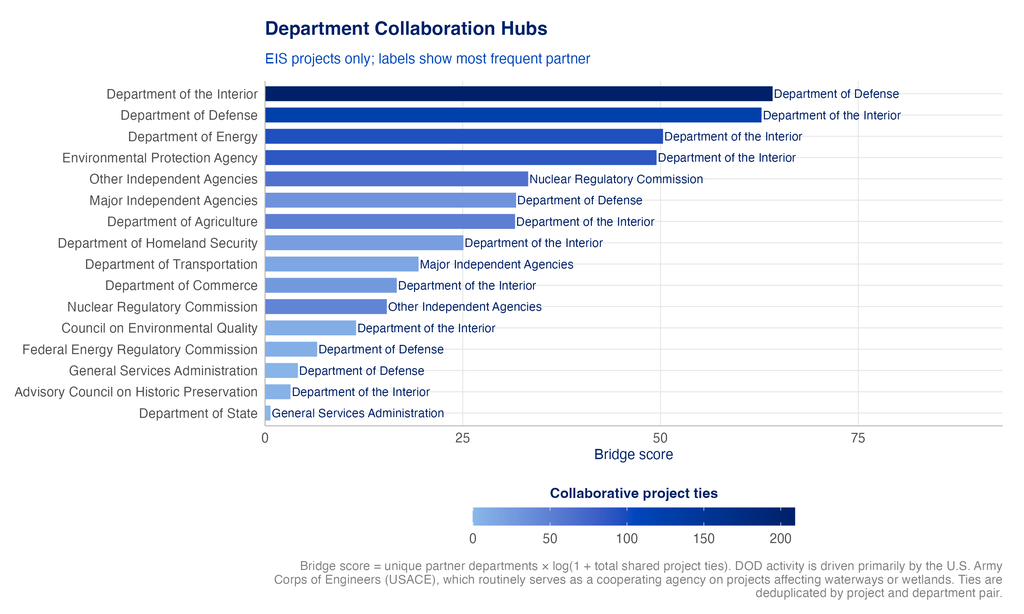

Figure 7: Department collaboration hubs from parsed EIS co-agency pairs. Bars show bridge score; labels show each department’s most frequent partner.

The parsed EIS co-agency network is broader than the strict metadata-only view. DOI, DOD, DOE, and EPA form the central cluster of department-level collaboration, with DOI carrying the largest number of collaborative project ties. This suggests that collaboration complexity is not only a DOE-centered metadata phenomenon; it also reflects EIS text signals where DOI, DOD, EPA, and USDA frequently appear as partners.

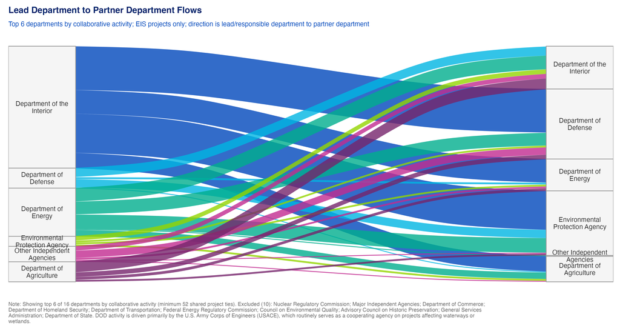

Figure 8: Cross-department project flows. Flow width reflects number of shared projects.

The Sankey adds direction to the same network by flowing from the lead or responsible department to cooperating or participating partner departments. This separates the directional coordination story from the undirected hub score: the hub figure asks which departments are most connected overall, while the Sankey asks which lead departments are connected to which named partner departments.

## Word Clouds by NEPA Process Type

The next three figures break multi-department project types out by NEPA process type. Because multi-department CEs and EAs are few (20 and 14 projects respectively), their word clouds reflect a narrow set of project types. EIS, which accounts for the bulk of the portfolio, shows the broadest vocabulary.

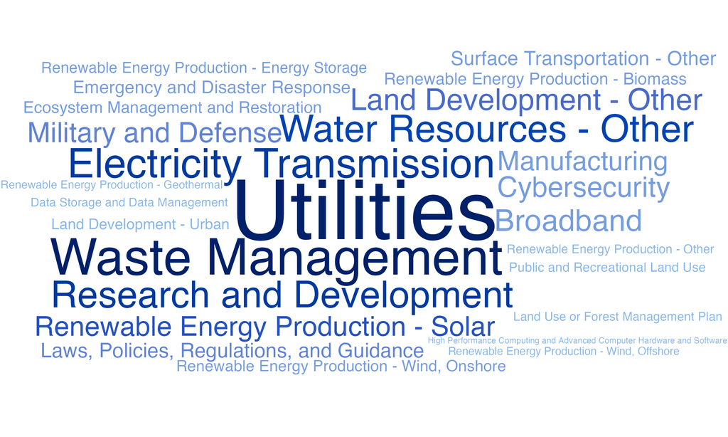

Figure 9: Multi-department project types word cloud for Categorical Exclusions (CE).

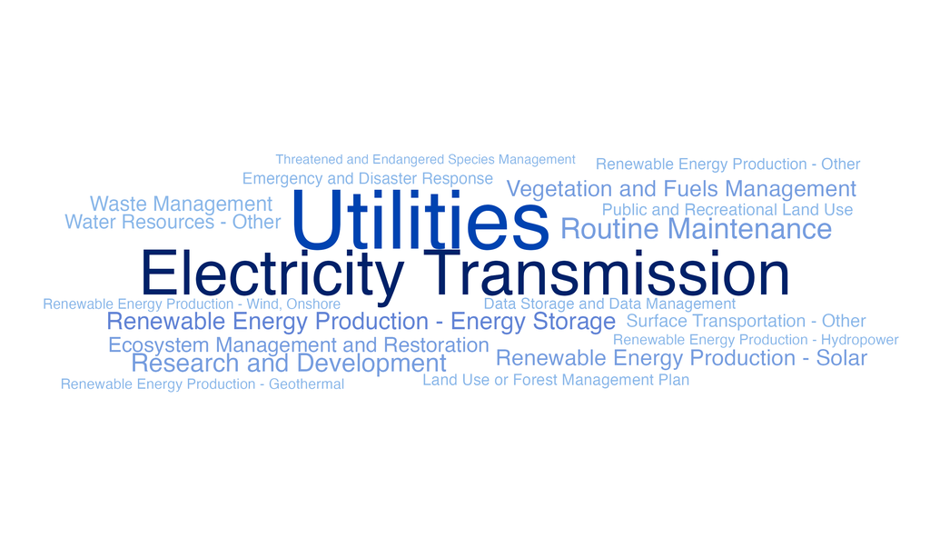

Figure 10: Multi-department project types word cloud for Environmental Assessments (EA).

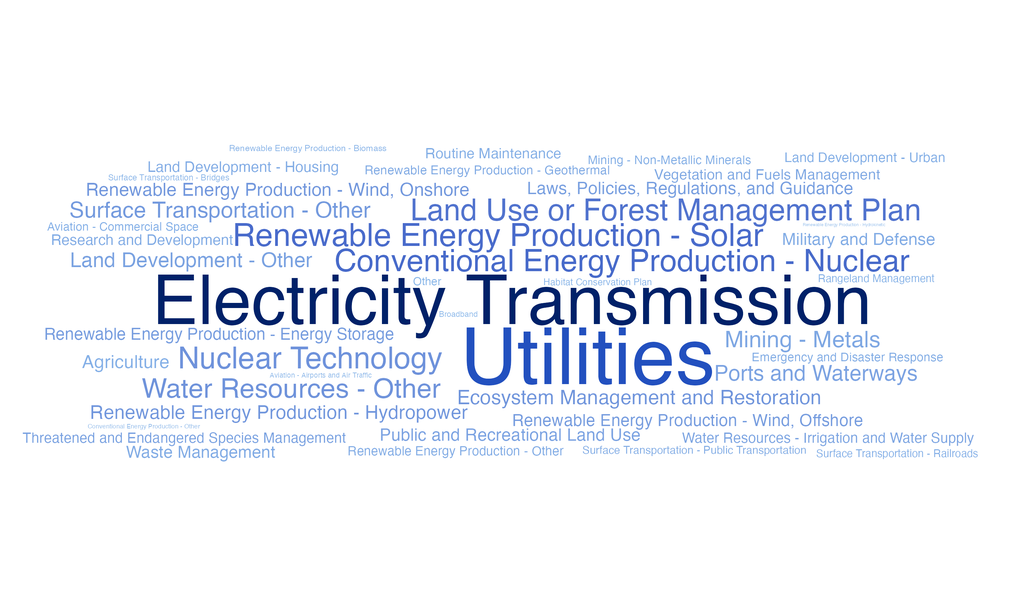

Figure 11: Multi-department project types word cloud for Environmental Impact Statements (EIS).

*Report generated 2026-08-21 | NEPA Decarbonization Technology Analysis*

## Footnotes

[^1]: State-pair tables are filtered to connections with 5+ shared projects and the map to 10+ shared projects, so Ns below Figure 1 are intentionally lower.